# Project

There’s a moment we all know too well.

You’re not planning a trip. You’re not even thinking about a trip. Then suddenly, **BAM**, a **€49 flight to Miami** pops up on your screen.

> “You could be on a beach next week.”

And just like that, your mind shifts from **“no trip”** to **“maybe I should go.”**  
But what exactly made that happen? Did the lower price *cause* you to consider flying, or were you already leaning toward taking a trip anyway?

This seemingly simple behavioral response lies at the heart of what economists call the **price elasticity of demand**: the extent to which consumers adjust their behavior when prices change.

For airlines, this elasticity shapes **pricing strategies** and **revenue management**. For governments, it determines the effectiveness of **taxes** and **subsidies**. For climate policy, it is particularly central, as air travel is one of the fastest-growing sources of greenhouse gas emissions worldwide.

While aviation currently accounts for approximately **2.5–3% of global greenhouse gas emissions** ([Our World in Data](https://ourworldindata.org/global-aviation-emissions); [BAFU](https://www.bafu.admin.ch/en/greenhouse-gas-emissions-from-aviation-2)), it is also one of the fastest-growing sources of emissions. Studies show that as passenger air travel has expanded rapidly over the last few decades, it has become a significant contributor to global carbon emissions. If this growth continues unchecked, the aviation sector’s share of global emissions is expected to rise even further—especially as airfares become more affordable and travel demand increases.

Yet despite the scale of air travel, we still lack a clean causal answer. Existing studies suggest that a **10% increase in ticket prices** is associated with a **5–8% drop in passenger numbers**, but these estimates vary widely across routes, time periods, and empirical approaches.

The core difficulty is simple: **prices and demand move together**. Airlines raise prices when they expect strong demand, and passengers adjust demand when they anticipate price changes. Untangling cause from effect is therefore far from straightforward.

In this project, we study this challenge in a concrete setting: **U.S. domestic air travel from the mid-1990s to 2025**. Using detailed route-level data, we examine how passenger demand responds to price changes as we progressively refine the empirical lens—moving from simple correlations to more careful causal strategies.

Before turning to the analysis, however, we need to step back and map the terrain in which prices and passengers interact.

```python
import os
from pathlib import Path
import warnings
warnings.filterwarnings("ignore", category=DeprecationWarning)

# Met ce chemin sur la racine de ton projet (là où il y a /scr et /data)
PROJECT_ROOT = Path().resolve()  # souvent ok dans VSCode
os.chdir(PROJECT_ROOT)

print("CWD =", Path().resolve())
print("scr exists:", Path("scr").exists())
print("data exists:", Path("data").exists())
```

```
CWD = /Users/oceanecarrillo/Documents/SMT E4S/Data Science/Project_Notebook
scr exists: True
data exists: True
```

```
[DAG] generating…
[DAG] saved → outputs/figures_simple_reg/dag_price_demand.png
[DAG] done.
[DATA] Loading data/merged_air_travel_data.csv ...
[DATA] Cleaned merged_air_travel_data: 118035 rows.
```

[output not shown]

```
[DATA] Aggregated panel (state → city → year) ready: 24932 observations.

[STATES] Running OLS (levels) with clustered SE (groups = route_id)

=== [STATES] OLS levels (total_passengers ~ avg_price) ===
                            OLS Regression Results
==============================================================================
Dep. Variable:       total_passengers   R-squared:                       0.003
Model:                            OLS   Adj. R-squared:                  0.003
Method:                 Least Squares   F-statistic:                    0.5430
Date:                Fri, 12 Dec 2025   Prob (F-statistic):              0.462
Time:                        17:55:55   Log-Likelihood:                -54633.
No. Observations:                5044   AIC:                         1.093e+05
Df Residuals:                    5042   BIC:                         1.093e+05
Df Model:                           1
Covariance Type:              cluster
==============================================================================
                 coef    std err          z      P>|z|      [0.025      0.975]
------------------------------------------------------------------------------
const       1.474e+04   3069.646      4.802      0.000    8723.466    2.08e+04
avg_price     -6.9163      9.386     -0.737      0.461     -25.312      11.479
==============================================================================
Omnibus:                     4237.369   Durbin-Watson:                   1.722
Prob(Omnibus):                  0.000   Jarque-Bera (JB):           109476.339
Skew:                           4.000   Prob(JB):                         0.00
Kurtosis:                      24.375   Cond. No.                         935.
==============================================================================

Notes:
[1] Standard Errors are robust to cluster correlation (cluster)
```

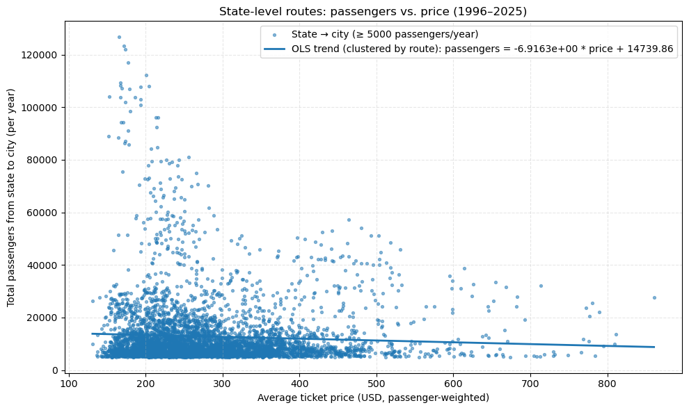

```
[PLOT] saved → outputs/figures_simple_reg/routes_states_price_x.png
```

[output not shown]

```
[CITIES] Running OLS (levels) with clustered SE (groups = route_id)

=== [CITIES] OLS levels (total_passengers ~ avg_price) ===
                            OLS Regression Results
==============================================================================
Dep. Variable:       total_passengers   R-squared:                       0.004
Model:                            OLS   Adj. R-squared:                  0.004
Method:                 Least Squares   F-statistic:                    0.6054
Date:                Fri, 12 Dec 2025   Prob (F-statistic):              0.437
Time:                        17:56:00   Log-Likelihood:                -48371.
No. Observations:                4586   AIC:                         9.675e+04
Df Residuals:                    4584   BIC:                         9.676e+04
Df Model:                           1
Covariance Type:              cluster
==============================================================================
                 coef    std err          z      P>|z|      [0.025      0.975]
------------------------------------------------------------------------------
const       1.312e+04   2340.675      5.606      0.000    8535.340    1.77e+04
avg_price     -5.7778      7.426     -0.778      0.437     -20.332       8.776
==============================================================================
Omnibus:                     3679.373   Durbin-Watson:                   1.881
Prob(Omnibus):                  0.000   Jarque-Bera (JB):            87188.300
Skew:                           3.752   Prob(JB):                         0.00
Kurtosis:                      22.999   Cond. No.                         889.
==============================================================================

Notes:
[1] Standard Errors are robust to cluster correlation (cluster)
```

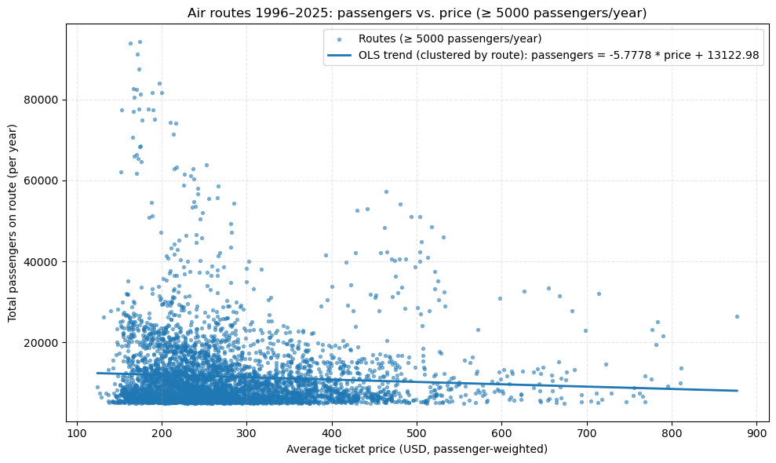

```
[PLOT] saved → outputs/figures_simple_reg/routes_cities_price_x.png
```

```python
%run scr/simple_regression.py
```

```
[INFO] Chargement de data/merged_air_travel_data.csv ...
[INFO] Données nettoyées: 118035 lignes.

[INFO] Construction du panel états (state → city → year) ...
```

[output not shown]

```
[INFO] Panel agrégé états → villes prêt : 24932 lignes.

======================================================================
[STATES] Elasticity (states → cities → year)
======================================================================

[INFO] Using clustered standard errors (groups = route_id)

=== [STATES] OLS log–log (raw) ===
                            OLS Regression Results
==============================================================================
Dep. Variable:                 ln_pax   R-squared:                       0.003
Model:                            OLS   Adj. R-squared:                  0.003
Method:                 Least Squares   F-statistic:                    0.6920
Date:                Fri, 12 Dec 2025   Prob (F-statistic):              0.406
Time:                        17:56:10   Log-Likelihood:                -4500.2
No. Observations:                5044   AIC:                             9004.
Df Residuals:                    5042   BIC:                             9018.
Df Model:                           1
Covariance Type:              cluster
==============================================================================
                 coef    std err          z      P>|z|      [0.025      0.975]
------------------------------------------------------------------------------
const          9.8579      0.759     12.994      0.000       8.371      11.345
ln_price      -0.1122      0.135     -0.832      0.405      -0.377       0.152
==============================================================================
Omnibus:                     1013.217   Durbin-Watson:                   1.867
Prob(Omnibus):                  0.000   Jarque-Bera (JB):             1834.547
Skew:                           1.267   Prob(JB):                         0.00
Kurtosis:                       4.521   Cond. No.                         106.
==============================================================================

Notes:
[1] Standard Errors are robust to cluster correlation (cluster)

=== [STATES] MLR log–log (with observed controls) ===
Controls used: []
                            OLS Regression Results
==============================================================================
Dep. Variable:                 ln_pax   R-squared:                       0.003
```

[output cut: 42 more lines]

```
Max Obs:                       226.00

                             Parameter Estimates
==============================================================================
            Parameter  Std. Err.     T-stat    P-value    Lower CI    Upper CI
------------------------------------------------------------------------------
const          13.097     0.3032     43.197     0.0000      12.503      13.692
ln_price      -0.6911     0.0542    -12.755     0.0000     -0.7974     -0.5849
==============================================================================

F-test for Poolability: 330.51
P-value: 0.0000
Distribution: F(284,4758)

Included effects: Entity, Time
```

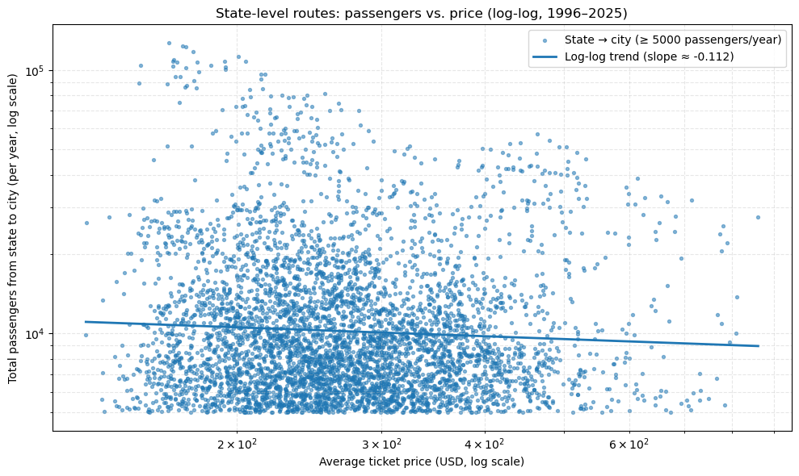

```
[STATES][PLOT] Saved: outputs/routes_states_loglog_price_x.png

======================================================================
[CITIES] Elasticity (city1 → city2 → year)
======================================================================

[INFO] Using clustered standard errors (groups = route_id)

=== [CITIES] OLS log–log (cities, cross-section) ===
                            OLS Regression Results
==============================================================================
Dep. Variable:                 ln_pax   R-squared:                       0.006
Model:                            OLS   Adj. R-squared:                  0.006
Method:                 Least Squares   F-statistic:                     1.114
Date:                Fri, 12 Dec 2025   Prob (F-statistic):              0.292
Time:                        17:56:15   Log-Likelihood:                -3675.1
No. Observations:                4586   AIC:                             7354.
Df Residuals:                    4584   BIC:                             7367.
Df Model:                           1
Covariance Type:              cluster
==============================================================================
                 coef    std err          z      P>|z|      [0.025      0.975]
------------------------------------------------------------------------------
const          9.9067      0.701     14.124      0.000       8.532      11.281
ln_price      -0.1317      0.125     -1.055      0.291      -0.376       0.113
==============================================================================
Omnibus:                      710.685   Durbin-Watson:                   0.185
Prob(Omnibus):                  0.000   Jarque-Bera (JB):             1109.918
Skew:                           1.083   Prob(JB):                    9.64e-242
Kurtosis:                       4.055   Cond. No.                         102.
==============================================================================

Notes:
[1] Standard Errors are robust to cluster correlation (cluster)

=== [CITIES] MLR log–log (with observed controls if any) ===
Controls used: []
                            OLS Regression Results
==============================================================================
Dep. Variable:                 ln_pax   R-squared:                       0.006
```

[output cut: 42 more lines]

```
Max Obs:                       227.00

                             Parameter Estimates
==============================================================================
            Parameter  Std. Err.     T-stat    P-value    Lower CI    Upper CI
------------------------------------------------------------------------------
const          12.707     0.2517     50.480     0.0000      12.214      13.201
ln_price      -0.6333     0.0451    -14.048     0.0000     -0.7217     -0.5449
==============================================================================

F-test for Poolability: 276.61
P-value: 0.0000
Distribution: F(289,4295)

Included effects: Entity, Time
```

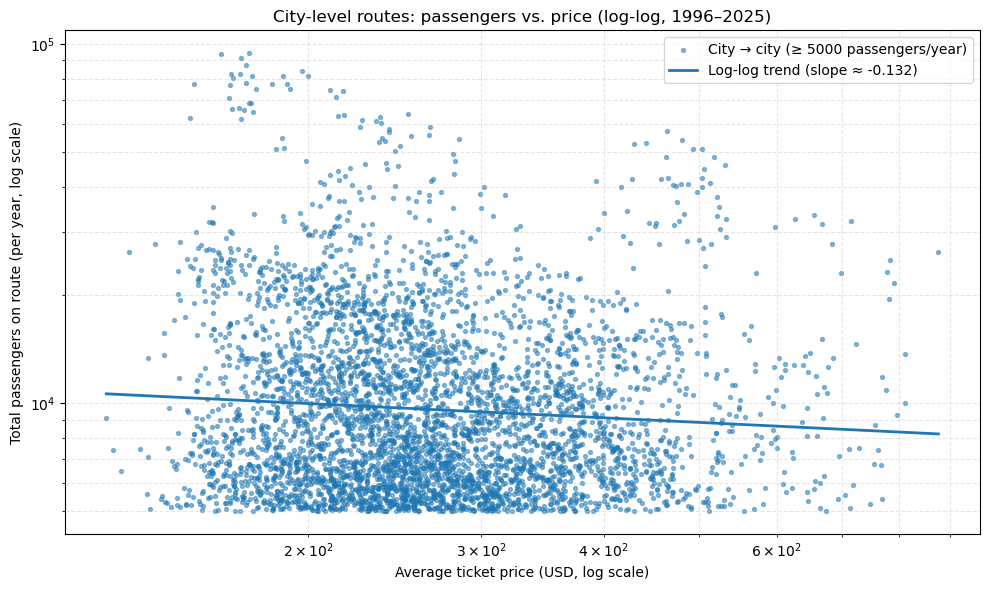

```
[CITIES][PLOT] Saved: outputs/routes_cities_loglog_price_x.png
```

```python
%run scr/elasticity_simple_reg.py
```

```python
from pathlib import Path
print("CWD:", Path.cwd())
print("Exists?", (Path("scr")/"endogeneity_from_merged.py").exists())
print("Files in scr:", [p.name for p in Path("scr").glob("*.py")])
```

```
CWD: /Users/oceanecarrillo/Documents/SMT E4S/Data Science/Project_Notebook
Exists? False
Files in scr: ['elasticity_reg_w_FE.py', 'Reverse_causality.py', 'Reverse_Causality_spec_curve.py', 'Litterature_technics_tax.py', 'Data_cleaning.py', 'Reverse_Causality _w_FE.py', 'endogeneity.py', 'elasticity_simple_reg.py', 'States_advanced_causal.py', 'simple_regression.py']
```

```
[INFO] Chargement du panel measuring cities depuis data/merged_air_travel_data.csv ...

[INFO] Agrégation annuelle (origin, destination, Year) ...

[INFO] Panel villes prêt : 29118 observations.

[INFO] Élasticité simple pour routes (villes): log_passengers ~ log_price
                            OLS Regression Results
==============================================================================
Dep. Variable:         log_passengers   R-squared:                       0.000
Model:                            OLS   Adj. R-squared:                  0.000
Method:                 Least Squares   F-statistic:                    0.4003
Date:                Fri, 12 Dec 2025   Prob (F-statistic):              0.527
Time:                        18:05:11   Log-Likelihood:                -36324.
No. Observations:               29118   AIC:                         7.265e+04
Df Residuals:                   29116   BIC:                         7.267e+04
Df Model:                           1
Covariance Type:              cluster
==============================================================================
                 coef    std err          z      P>|z|      [0.025      0.975]
------------------------------------------------------------------------------
Intercept      7.0347      0.274     25.644      0.000       6.497       7.572
log_price     -0.0307      0.049     -0.633      0.527      -0.126       0.064
==============================================================================
Omnibus:                     2406.588   Durbin-Watson:                   1.662
Prob(Omnibus):                  0.000   Jarque-Bera (JB):             3051.321
Skew:                          -0.789   Prob(JB):                         0.00
Kurtosis:                       3.167   Cond. No.                         103.
==============================================================================

Notes:
[1] Standard Errors are robust to cluster correlation (cluster)

[INFO] Aucune colonne distance trouvée pour routes (villes) -> hétérogénéité par distance sautée.

[INFO] Chargement du panel états (reconstruit depuis data/merged_air_travel_data.csv) ...

[INFO] Construction du panel états (state → city → year) depuis data/merged_air_travel_data.csv ...
```

[output not shown]

```
[INFO] Panel agrégé états → villes prêt : 24932 lignes.

[INFO] Panel états prêt : 24932 observations.

[INFO] Descriptives par état-destination ...

[INFO] Descriptives par état (agrégées sur toutes les destinations) ...

[INFO] Plot mean price vs mean passengers par état ...

[INFO] Figure sauvegardée : outputs/figures_endogeneity/mean_price_vs_pax_by_state.png
```

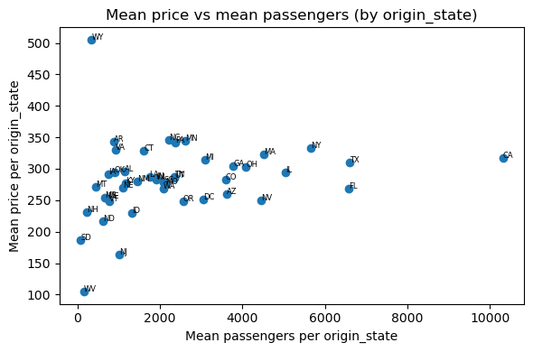

```
[INFO] Élasticité simple pour états -> destinations: log_passengers ~ log_price
                            OLS Regression Results
==============================================================================
Dep. Variable:         log_passengers   R-squared:                       0.006
Model:                            OLS   Adj. R-squared:                  0.006
Method:                 Least Squares   F-statistic:                     9.649
Date:                Fri, 12 Dec 2025   Prob (F-statistic):            0.00194
Time:                        18:05:15   Log-Likelihood:                -40602.
No. Observations:               24932   AIC:                         8.121e+04
Df Residuals:                   24930   BIC:                         8.122e+04
Df Model:                           1
Covariance Type:              cluster
==============================================================================
                 coef    std err          z      P>|z|      [0.025      0.975]
------------------------------------------------------------------------------
Intercept      9.2508      0.568     16.277      0.000       8.137      10.365
log_price     -0.3113      0.100     -3.106      0.002      -0.508      -0.115
==============================================================================
Omnibus:                        0.591   Durbin-Watson:                   1.734
Prob(Omnibus):                  0.744   Jarque-Bera (JB):                0.577
Skew:                           0.011   Prob(JB):                        0.750
Kurtosis:                       3.009   Cond. No.                         105.
==============================================================================

Notes:
[1] Standard Errors are robust to cluster correlation (cluster)

[INFO] Élasticité au niveau national (agrégation par année à partir des états) ...
                            OLS Regression Results
==============================================================================
Dep. Variable:         log_passengers   R-squared:                       0.002
Model:                            OLS   Adj. R-squared:                 -0.034
Method:                 Least Squares   F-statistic:                   0.02764
Date:                Fri, 12 Dec 2025   Prob (F-statistic):              0.869
Time:                        18:05:15   Log-Likelihood:                 3.3811
No. Observations:                  30   AIC:                            -2.762
Df Residuals:                      28   BIC:                           0.04025
Df Model:                           1
Covariance Type:                  HC1
==============================================================================
```

[output cut: 110 more lines]

```
[INFO] Aucun instrument trouvé dans les colonnes -> spec IV sautée.

[INFO] Tableau de robustesse sauvegardé : robustness_elasticities_states.csv

[INFO] Simulation d'une taxe / hausse de prix ...

[INFO] Année: 2025

[INFO] Baseline passengers: 2,056,338

[INFO] Elasticity: -0.975, ΔP/P = 0.10

[INFO] Predicted ΔQ/Q = -0.098

[INFO] New passengers (approx.): 1,855,801
```

```python
%run scr/endogeneity.py
```

```python
%run scr/Reverse_Causality _w_FE.py
```

```
[INFO] Chargement des données trimestrielles (villes) depuis data/merged_air_travel_data.csv ...

[INFO] Agrégation au niveau annuel (city1, city2, Year) ...

[INFO] Panel villes prêt : 27305 observations avec lag de prix dispo.

[INFO] Saved prepared city panel: outputs/results_reverse_causality/panel_cities_lag.csv

[INFO] OLS lag model pour villes (city1 -> city2, annuel) : ln_pax_t ~ ln_price_lag1

[INFO] SE clusterisées sur route_id
                            OLS Regression Results
==============================================================================
Dep. Variable:                 ln_pax   R-squared:                       0.002
Model:                            OLS   Adj. R-squared:                  0.002
Method:                 Least Squares   F-statistic:                     5.333
Date:                Fri, 12 Dec 2025   Prob (F-statistic):             0.0211
Time:                        17:58:10   Log-Likelihood:                -32897.
No. Observations:               27305   AIC:                         6.580e+04
Df Residuals:                   27303   BIC:                         6.581e+04
Df Model:                           1
Covariance Type:              cluster
=================================================================================
                    coef    std err          z      P>|z|      [0.025      0.975]
---------------------------------------------------------------------------------
Intercept         7.5429      0.276     27.318      0.000       7.002       8.084
ln_price_lag1    -0.1126      0.049     -2.309      0.021      -0.208      -0.017
==============================================================================
Omnibus:                     2281.040   Durbin-Watson:                   0.402
Prob(Omnibus):                  0.000   Jarque-Bera (JB):             2895.380
Skew:                          -0.791   Prob(JB):                         0.00
Kurtosis:                       3.210   Cond. No.                         104.
==============================================================================

Notes:
[1] Standard Errors are robust to cluster correlation (cluster)

[INFO] Panel FE (route & année) pour villes (city1 -> city2, annuel) ...
                          PanelOLS Estimation Summary
================================================================================
```

[output cut: 21 more lines]

```
const             10.623     0.2446     43.423     0.0000      10.144      11.103
ln_price_lag1    -0.6558     0.0431    -15.201     0.0000     -0.7403     -0.5712
=================================================================================

F-test for Poolability: 48.055
P-value: 0.0000
Distribution: F(1618,25685)

Included effects: Entity, Time

[INFO] Saved city results: outputs/results_reverse_causality/results_cities.csv

[INFO] Préparation du panel états (origin_state -> city2, annuel) depuis data/merged_air_travel_data.csv ...

[INFO] Construction du panel états (state → city → year) depuis data/merged_air_travel_data.csv ...
```

[output not shown]

```
[INFO] Panel agrégé états → villes prêt : 24932 lignes.

[INFO] Panel états prêt : 23682 observations avec lag de prix dispo.

[INFO] Saved prepared state panel: outputs/results_reverse_causality/panel_states_lag.csv

[INFO] OLS lag model pour états (origin_state -> city2, annuel) : ln_pax_t ~ ln_price_lag1

[INFO] SE clusterisées sur route_id
                            OLS Regression Results
==============================================================================
Dep. Variable:                 ln_pax   R-squared:                       0.010
Model:                            OLS   Adj. R-squared:                  0.010
Method:                 Least Squares   F-statistic:                     14.42
Date:                Fri, 12 Dec 2025   Prob (F-statistic):           0.000154
Time:                        17:58:14   Log-Likelihood:                -38008.
No. Observations:               23682   AIC:                         7.602e+04
Df Residuals:                   23680   BIC:                         7.604e+04
Df Model:                           1
Covariance Type:              cluster
=================================================================================
                    coef    std err          z      P>|z|      [0.025      0.975]
---------------------------------------------------------------------------------
Intercept         9.7205      0.576     16.874      0.000       8.591      10.850
ln_price_lag1    -0.3854      0.102     -3.797      0.000      -0.584      -0.186
==============================================================================
Omnibus:                       10.955   Durbin-Watson:                   0.206
Prob(Omnibus):                  0.004   Jarque-Bera (JB):               10.940
Skew:                           0.051   Prob(JB):                      0.00421
Kurtosis:                       3.027   Cond. No.                         106.
==============================================================================

Notes:
[1] Standard Errors are robust to cluster correlation (cluster)

[INFO] Panel FE (route & année) pour états (origin_state -> city2, annuel) ...
                          PanelOLS Estimation Summary
================================================================================
Dep. Variable:                 ln_pax   R-squared:                        0.1146
Estimator:                   PanelOLS   R-squared (Between):             -0.2358
```

[output cut: 15 more lines]

```
                               Parameter Estimates
=================================================================================
               Parameter  Std. Err.     T-stat    P-value    Lower CI    Upper CI
---------------------------------------------------------------------------------
const             12.339     0.2171     56.839     0.0000      11.914      12.765
ln_price_lag1    -0.8485     0.0384    -22.105     0.0000     -0.9237     -0.7732
=================================================================================

F-test for Poolability: 233.62
P-value: 0.0000
Distribution: F(1172,22508)

Included effects: Entity, Time

[INFO] Saved state results: outputs/results_reverse_causality/results_states.csv
```